# Data Science Project 2 - Return to Education and Income in the United States (2023)

Constantine Zhang

Ha Nguyen

Kemal Ege Sural

2025-12-14

```r
acs_raw <- read.csv("acs2023.csv")
df <- acs_raw # copy


#Renaming

names(df)[names(df) == "inctot"]           <- "total_income"
names(df)[names(df) == "real_gdp"]         <- "state_real_gdp"
names(df)[names(df) == "real_pc_income"]   <- "state_pc_income"
names(df)[names(df) == "total_employment"] <- "state_total_jobs"

names(df)[names(df) == "educ"]     <- "education"
names(df)[names(df) == "age"]      <- "age"
names(df)[names(df) == "sex"]      <- "gender"
names(df)[names(df) == "race"]     <- "race"
names(df)[names(df) == "marst"]    <- "marital_status"
names(df)[names(df) == "nchild"]   <- "num_children"
names(df)[names(df) == "citizen"]  <- "citizenship"
names(df)[names(df) == "empstat"]  <- "employment_status"
names(df)[names(df) == "labforce"] <- "labor_force"
names(df)[names(df) == "perwt"]    <- "person_weight"

#Factor changes

df$gender <- factor(df$gender,
                    levels = c(1, 2),
                    labels = c("Male", "Female"))

df$marital_status <- factor(df$marital_status, levels = 1:6,
                            labels = c("Married (Present)", "Married (Absent)",
                                       "Separated", "Divorced", "Widowed", "Single"))


df$race <- factor(df$race, levels = 1:6,
                  labels = c("White", "Black", "Native American",
                             "Chinese", "Japanese", "Other Asian/Pacific"))

df$citizenship <- factor(df$citizenship, levels = 1:3,
                         labels = c("Born Abroad (US Parents)",
                                    "Naturalized Citizen",
                                    "Not a Citizen"))

df$employment_status <- factor(df$employment_status, levels = 1:3,
                               labels = c("Employed", "Unemployed", "Not in Labor Force"))

df$labor_force <- factor(df$labor_force, levels = 1:2,
                         labels = c("Not in Labor Force", "In Labor Force"))


df$education_level <- factor(df$education, levels = 1:11,
                             labels = c("Nursery-Gr4", "Gr5-8", "Gr9", "Gr10", "Gr11", "Gr12",
                                        "1yr College", "2yr College", "3yr College", "4yr College", "5+yr College"))


df$educ_group <- NA
df$educ_group[df$education <= 6] <- "HS or Less"
df$educ_group[df$education %in% c(7, 8, 9)] <- "Some College"
df$educ_group[df$education == 10] <- "Bachelor's"
df$educ_group[df$education == 11] <- "Post-Grad"
df$educ_group <- factor(df$educ_group, levels = c("HS or Less", "Some College", "Bachelor's", "Post-Grad"))

#Removing NA/ 0 INCOME
df <- na.omit(df)
df <- df[df$total_income > 0, ]
```

# 1 Literature Review & Motivation

This research project examines the economic returns to education in the United States, building on established findings in labor economics. The literature review highlights three key foundational studies:

These studies collectively motivate an investigation into how educational returns vary across different populations and economic contexts. While the relationship between education and earnings is well-established, important questions remain about heterogeneity in returns across demographic groups and geographic regions with different economic conditions.

# 2 Dataset Overview

## 2.1 Overview:

The analysis combines two complementary data sources from 2023, yielding 229,342 observations after cleaning and merging:

**1. American Community Survey (ACS)*** from IPUMS provides individual-level micro-data including education levels, demographic characteristics, labor force status, and total income. This nationally representative dataset enables estimation of returns to education and subgroup analysis across gender, race, age, and nativity.

**2. State Annual Summary Statistics** from the U.S. Bureau of Economic Analysis (BEA) offers macroeconomic indicators including real GDP, GDP per capita, and total employment. These variables allow the research to control for state-level economic conditions that may influence educational returns.

Total number of variables: 17, details as below:

```r
print(names(df))
```

```
##  [1] "statefip"          "person_weight"     "num_children"
##  [4] "gender"            "age"               "marital_status"
##  [7] "race"              "citizenship"       "education"
## [10] "employment_status" "labor_force"       "total_income"
## [13] "state_real_gdp"    "state_pc_income"   "state_total_jobs"
## [16] "education_level"   "educ_group"
```

## 2.2 Data Limitations

The ACS data has several important constraints:

- Cross-sectional only: cannot infer causality or follow individuals over time.
- Income measurement error: self-reported income, top-coding, and under-reporting among high earners.
- Coarse education categories: no detail on field of study, institution quality, degree type, or credentials.
- Small subgroup samples: certain demographic groups in smaller states have limited sample sizes, increasing variance.

The state-level economic data uses broad state averages that may obscure local labor market differences between urban and rural areas or specific industry clusters.

# 3 Smart Questions

The project explores two primary questions:

1. *What is the relationship between annual income and levels of education, after accounting for demographic and state-level economic variables?* This question seeks to quantify the income premium associated with different educational attainment levels while controlling for confounding factors.
2. *How does the return to education vary by demographic subgroups and across states with differing economic conditions?* This question investigates heterogeneity in educational returns, examining whether the economic benefits of education differ systematically across gender, race, age groups, and geographic regions with varying economic characteristics.

Together, these questions aim to provide a understanding of educational returns in the U.S, accounting for both individual characteristics and state economic contexts.

# 4 EDA

## 4.1 Statistics summary and plot

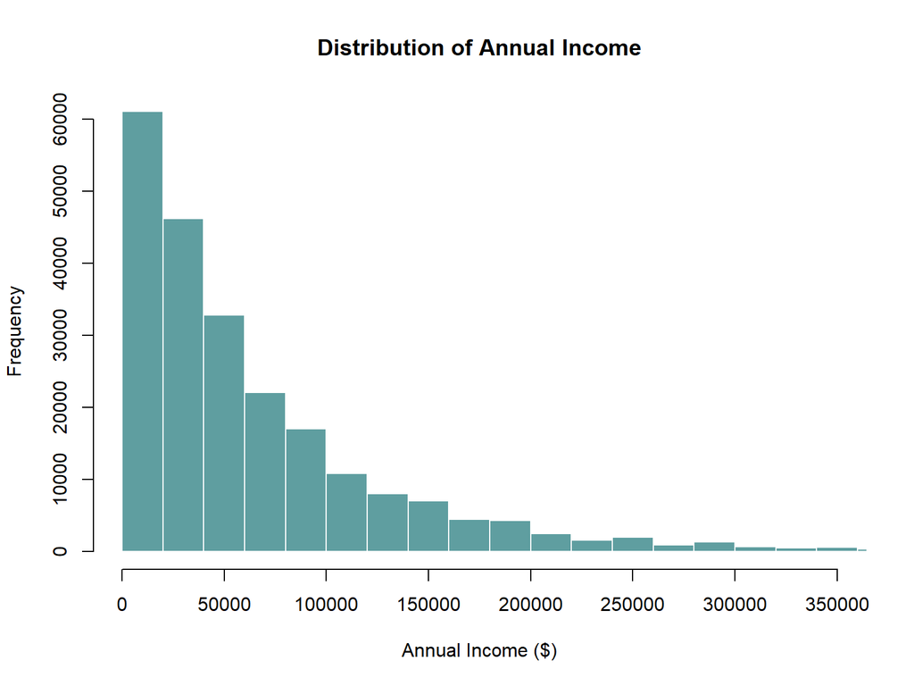

```r
#  Income distribution
par(mfrow = c(1, 1))

hist(df$total_income,
     breaks = 100,
     xlim = c(0, 350000),
     main = "Distribution of Annual Income",
     xlab = "Annual Income ($)",
     ylab = "Frequency",
     col = "cadetblue",
     border = "white")
```

The histogram is right-skewed, showing that most incomes are low while a few high-income outliers form a long tail to the right. Because these outliers pull the mean upward, the median is a more accurate measure of the typical income.

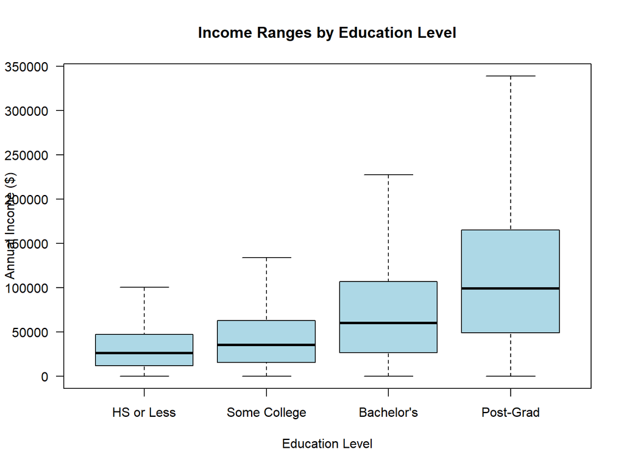

```r
# Income by Education level
boxplot(total_income ~ educ_group, data = df,
        main = "Income Ranges by Education Level",
        xlab = "Education Level",
        ylab = "Annual Income ($)",
        col = "lightblue",
        outline = FALSE,
        las = 1)
```

```r
# Median Income

cat("Median Income by Education Level Table")
```

```
## Median Income by Education Level Table
```

```r
income_by_educ <- aggregate(total_income ~ educ_group, data = df, FUN = median)
print(income_by_educ)
```

```
##     educ_group total_income
## 1   HS or Less        26000
## 2 Some College        35400
## 3   Bachelor's        60000
## 4    Post-Grad        99000
```

The boxplots shows a clear positive link between education and income. As education levels rise, the median income consistently increases. However, the variance of salaries also gets much wider with higher education. While high school graduates earn within a narrow, consistent range, the “Post-Grad” group has a very tall box and long whiskers, indicating a huge gap between the lowest and highest earners in that category.

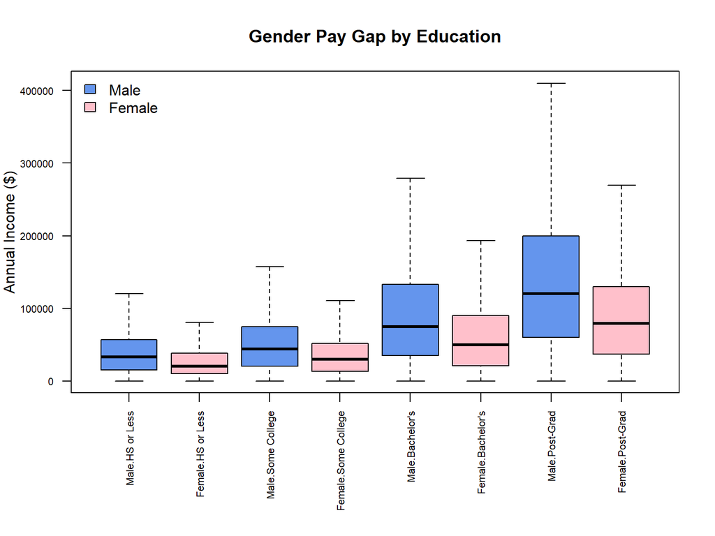

```r
# Gender income difference by education
par(mar = c(8, 4, 4, 2))
boxplot(total_income ~ gender * educ_group, data = df,
        main = "Gender Pay Gap by Education",
        xlab='',
        ylab = "Annual Income ($)",
        col = c("cornflowerblue", "pink"), # Mavi=Erkek, Pembe=Kadın
        outline = FALSE,
        las = 2,
        cex.axis = 0.7) # Yazı boyutunu biraz küçült

legend("topleft", legend = c("Male", "Female"),
       fill = c("cornflowerblue", "pink"), bty = "n")
```

The graph compares incomes for men and women across different education levels. It clearly shows that in every category, men have a higher median income than women. This pay gap gets much wider as education levels rise. While the difference is smaller for high school graduates, it becomes very large for the “Post-Grad” group, where men earn significantly more than women even with the same level of education.

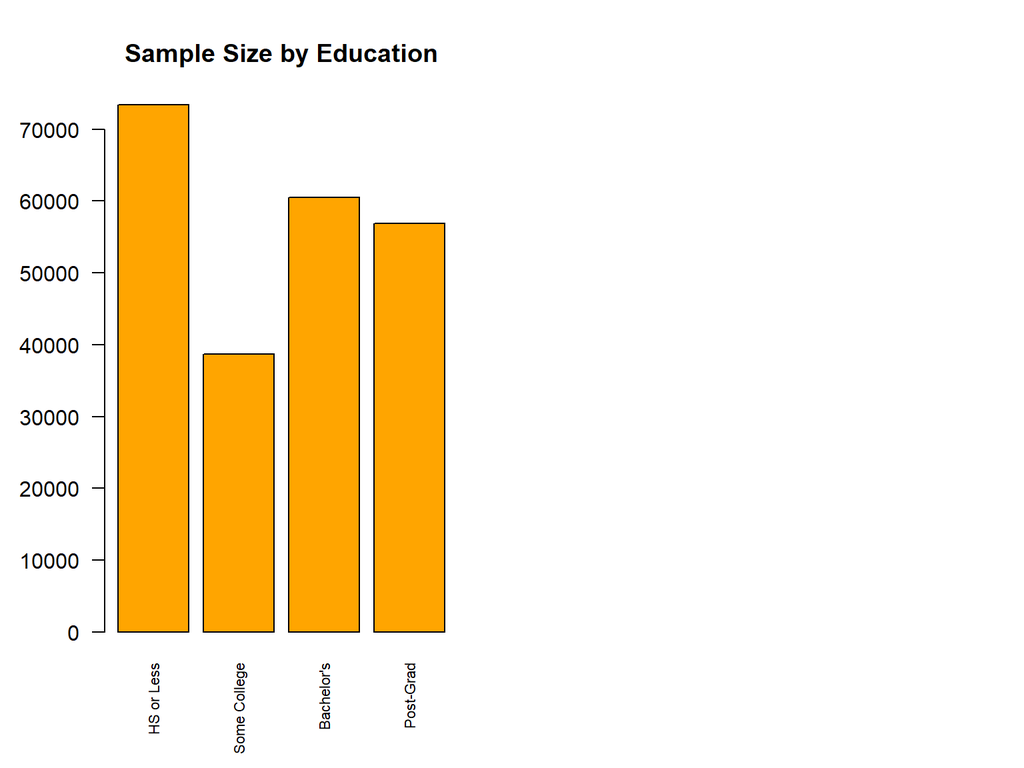

```r
# Categoric
par(mfrow = c(1, 2))

# Education
educ_counts <- table(df$educ_group)
barplot(educ_counts,
        main = "Sample Size by Education",
        col = "orange",
        las = 2,
        cex.names = 0.7)
```

This chart counts how many people in the study have different levels of education. The biggest group is people with a high school education or less. The smallest group is people with only some college experience.

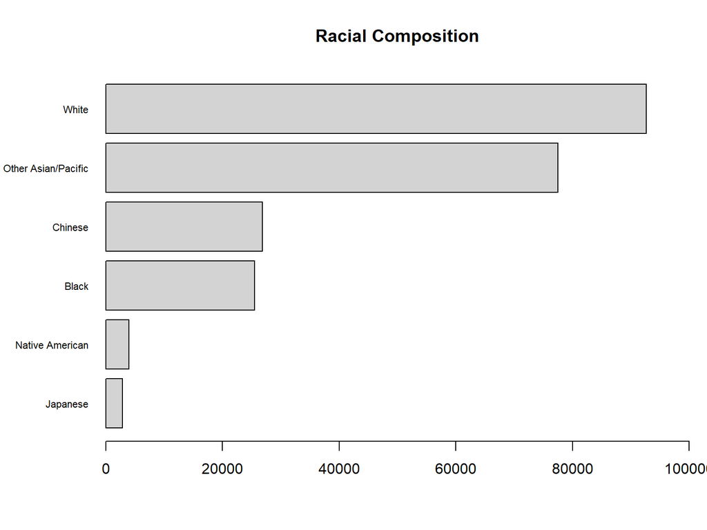

```r
# Race
race_counts <- sort(table(df$race), decreasing = FALSE)
par(mar=c(5, 6, 4, 1))
barplot(race_counts,
        main = "Racial Composition",
        xlim = c(0,100000),
        horiz = TRUE,
        col = "lightgray",
        las = 1,
        cex.names = 0.7)
```

This chart shows the race of the people in the study. The vast majority of people are White or from the “Other Asian/Pacific” group. On the other hand, there are very few Native American or Japanese participants.

## 4.2 Hypothesis Testing

### 4.2.1 ANOVA (Analysis of Variance) for Educational Level

Research Question: Does education level result in a statistically significant difference in income?

H0 (Null Hypothesis): The mean income of all education groups is equal.

H1 (Alternative Hypothesis): At least one group’s income is different from the others.

```r
anova <- aov(log(total_income) ~ educ_group, data = df)

print(summary(anova))
```

```
##                 Df Sum Sq Mean Sq F value              Pr(>F)
## educ_group       3  60432   20144   13868 <0.0000000000000002 ***
## Residuals   229338 333133       1
## ---
## Signif. codes:  0 '***' 0.001 '**' 0.01 '*' 0.05 '.' 0.1 ' ' 1
```

A one-way ANOVA test was conducted to determine if education level creates a statistically significant difference in income. The results indicate a strong relationship, with a high F-value ($13,868$) and a p-value of less than 0.001. Because the p-value is extremely low, we reject the null hypothesis and confirm that income levels vary significantly across education groups. However, since the ANOVA does not specify which groups differ, a post-hoc test is required to identify the specific differences.

```r
tukey<- TukeyHSD(anova)

print(tukey)
```

```
##   Tukey multiple comparisons of means
##     95% family-wise confidence level
##
## Fit: aov(formula = log(total_income) ~ educ_group, data = df)
##
## $educ_group
##                          diff   lwr   upr p adj
## Some College-HS or Less 0.273 0.254 0.292     0
## Bachelor's-HS or Less   0.790 0.773 0.807     0
## Post-Grad-HS or Less    1.300 1.282 1.317     0
## Bachelor's-Some College 0.517 0.497 0.537     0
## Post-Grad-Some College  1.027 1.006 1.047     0
## Post-Grad-Bachelor's    0.510 0.491 0.528     0
```

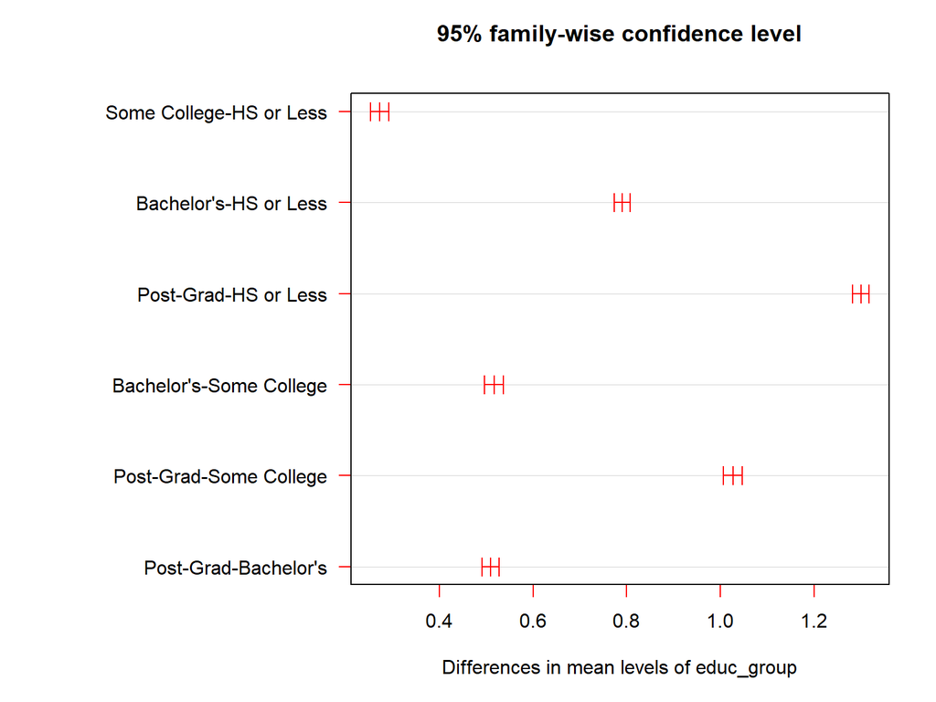

```r
par(mar=c(5, 15, 4, 2))
plot(tukey, las=1, col="red")
```

The results show that every single pairwise comparison is statistically significant. This confirms a clear hierarchy in earnings: those with ‘High School or Less’ earn the lowest, followed by ‘Some College’ and ‘Bachelor’s’, while the ‘Post-Grad’ group has the highest income. In short, each step up in education level results in a statistically significant increase in total income.

### 4.2.2 T-Test (Independent Samples) for Genders

Research Question: Is there a difference between the mean incomes of males and females?

H0 (Null Hypothesis): The mean incomes of males and females are EQUAL.

H1 (Alternative Hypothesis): The mean incomes of males and females are NOT EQUAL.

```r
t_test <- t.test(log(total_income) ~ gender, data = df)
print(t_test)
```

```
##
##  Welch Two Sample t-test
##
## data:  log(total_income) by gender
## t = 88, df = 229081, p-value <0.0000000000000002
## alternative hypothesis: true difference in means between group Male and group Female is not equal to 0
## 95 percent confidence interval:
##  0.460 0.482
## sample estimates:
##   mean in group Male mean in group Female
##                 10.8                 10.3
```

A Welch Two Sample t-test was conducted to compare the average incomes of male and female groups. The results indicate a highly significant difference between the two genders ($t = 88, p < 0.001$). The analysis shows that the average log-income for males ($10.8$) is higher than the average log-income for females ($10.3$). Additionally, the 95% confidence interval is entirely positive ($0.46$ to $0.48$), which confirms that males consistently earn more than females in this dataset. Based on this, the null hypothesis is rejected.

### 4.2.3 Pearson Correlation Test - Income vs State GDP

Research Question: To what extent is an individual’s total income associated with the economic prosperity (GDP) of their state?

H0 (Null Hypothesis): There is NO linear correlation between individual income and state-level GDP.

H1 (Alternative Hypothesis): There is a statistically significant linear correlation between individual income and state-level GDP.

```r
cor_test <- cor.test(log(df$total_income), log(df$state_real_gdp), method = "pearson")
print(cor_test)
```

```
##
##  Pearson's product-moment correlation
##
## data:  log(df$total_income) and log(df$state_real_gdp)
## t = 14, df = 229340, p-value <0.0000000000000002
## alternative hypothesis: true correlation is not equal to 0
## 95 percent confidence interval:
##  0.0260 0.0341
## sample estimates:
##    cor
## 0.0301
```

A Pearson correlation test was conducted to examine the relationship between state-level GDP and individual total income.

The results show a statistically significant relationship ($t = 14, p < 0.001$). However, the correlation coefficient is extremely low ($r = 0.03$). This indicates that although there is a positive association between the wealth of a region and personal income, the relationship is negligible. In other words, living in a richer state has almost no direct impact on an individual’s income in this dataset.

# 5 Regression

## 5.1 Plot of correlation

Because our main explanatory variable is categorical, we do not use a standard correlation matrix for this section.

For a numerical variable and a categorical variable, we use the eta method to determine the correlation.

```r
etaSquared(aov( total_income ~ education_level, data = df))
```

```
##                 eta.sq eta.sq.part
## education_level  0.141       0.141
```

```r
eta_value <- function(cat, num) {
  as.numeric(etaSquared(aov(num ~ cat))[1])
}

eta_value(df$education_level, df$total_income)
```

```
## [1] 0.141
```

This result implies that education level explains 14.1% of the variation in total income. This is on the threshold of a large effect, which means education level has a meaningful and strong association with personal total income.

## 5.2 Run regression

```r
df$education_level <- factor(df$educ_group)
df$race <- factor(df$race)
df$gender <- factor(df$gender)
df$race <- relevel(df$race, ref = "White")
df$gender <- relevel(df$gender, ref = "Male")
df$educ_group <- relevel(df$educ_group, ref = "HS or Less")
```

### 5.2.1 linear regression without control

```r
model.base <- lm( log(total_income) ~ educ_group, data = df)
summary(model.base)
```

```
##
## Call:
## lm(formula = log(total_income) ~ educ_group, data = df)
##
## Residuals:
##     Min      1Q  Median      3Q     Max
## -10.782  -0.591   0.203   0.766   3.963
##
## Coefficients:
##                        Estimate Std. Error t value            Pr(>|t|)
## (Intercept)             9.99189    0.00445    2246 <0.0000000000000002 ***
## educ_groupSome College  0.27300    0.00757      36 <0.0000000000000002 ***
## educ_groupBachelor's    0.79005    0.00662     119 <0.0000000000000002 ***
## educ_groupPost-Grad     1.29962    0.00673     193 <0.0000000000000002 ***
## ---
## Signif. codes:  0 '***' 0.001 '**' 0.01 '*' 0.05 '.' 0.1 ' ' 1
##
## Residual standard error: 1.21 on 229338 degrees of freedom
## Multiple R-squared:  0.154,  Adjusted R-squared:  0.154
## F-statistic: 1.39e+04 on 3 and 229338 DF,  p-value: <0.0000000000000002
```

### 5.2.2 linear regression with control for gender, age, and race

```r
model.gender.race <- lm( log(total_income) ~ educ_group + gender + race + age , data = df)
summary(model.gender.race)
```

```
##
## Call:
## lm(formula = log(total_income) ~ educ_group + gender + race +
##     age, data = df)
##
## Residuals:
##     Min      1Q  Median      3Q     Max
## -11.014  -0.560   0.199   0.760   4.061
##
## Coefficients:
##                          Estimate Std. Error t value             Pr(>|t|)
## (Intercept)             10.179298   0.010027 1015.19 < 0.0000000000000002 ***
## educ_groupSome College   0.280460   0.007480   37.50 < 0.0000000000000002 ***
## educ_groupBachelor's     0.797630   0.006627  120.35 < 0.0000000000000002 ***
## educ_groupPost-Grad      1.279621   0.006747  189.65 < 0.0000000000000002 ***
## genderFemale            -0.430541   0.004970  -86.64 < 0.0000000000000002 ***
## raceBlack               -0.097651   0.008442  -11.57 < 0.0000000000000002 ***
## raceNative American     -0.062871   0.019452   -3.23              0.00123 **
## raceChinese             -0.082516   0.008279   -9.97 < 0.0000000000000002 ***
## raceJapanese            -0.075074   0.022538   -3.33              0.00087 ***
## raceOther Asian/Pacific -0.023678   0.005843   -4.05             0.000051 ***
## age                      0.001234   0.000144    8.57 < 0.0000000000000002 ***
## ---
## Signif. codes:  0 '***' 0.001 '**' 0.01 '*' 0.05 '.' 0.1 ' ' 1
##
## Residual standard error: 1.19 on 229331 degrees of freedom
## Multiple R-squared:  0.182,  Adjusted R-squared:  0.182
## F-statistic: 5.09e+03 on 10 and 229331 DF,  p-value: <0.0000000000000002
```

This specification, with age, gender, and race as controls, has a higher R-squared value. We also find that all coefficients are statistically significant. However, this specification only allows differences in intercepts, not slopes, across race and gender.

Based on the simple regression model, education has an increasingly strong influence on personal income with each additional level of education a person acquire, and all of these coefficients are statistically significant.

### 5.2.3 linear regression with interaction terms for gender, age, and race

```r
model.interaction <- lm( log(total_income) ~  educ_group   * gender + educ_group* race + gender * race +  +age  , data = df)
summary(model.interaction)
```

```
##
## Call:
## lm(formula = log(total_income) ~ educ_group * gender + educ_group *
##     race + gender * race + +age, data = df)
##
## Residuals:
##     Min      1Q  Median      3Q     Max
## -11.076  -0.554   0.199   0.753   4.065
##
## Coefficients:
##                                                 Estimate Std. Error t value
## (Intercept)                                    10.240255   0.011513  889.46
## educ_groupSome College                          0.279282   0.013622   20.50
## educ_groupBachelor's                            0.794557   0.012271   64.75
## educ_groupPost-Grad                             1.209309   0.012210   99.04
## genderFemale                                   -0.505294   0.010476  -48.24
## raceBlack                                      -0.236369   0.015869  -14.89
## raceNative American                            -0.082754   0.028276   -2.93
## raceChinese                                    -0.368684   0.017805  -20.71
## raceJapanese                                    0.069478   0.055716    1.25
## raceOther Asian/Pacific                        -0.171548   0.012315  -13.93
## age                                             0.001379   0.000144    9.55
## educ_groupSome College:genderFemale             0.016856   0.014953    1.13
## educ_groupBachelor's:genderFemale              -0.071498   0.013203   -5.42
## educ_groupPost-Grad:genderFemale               -0.074396   0.013466   -5.52
## educ_groupSome College:raceBlack               -0.006545   0.022406   -0.29
## educ_groupBachelor's:raceBlack                 -0.054693   0.022736   -2.41
## educ_groupPost-Grad:raceBlack                  -0.106772   0.023910   -4.47
## educ_groupSome College:raceNative American     -0.046250   0.054802   -0.84
## educ_groupBachelor's:raceNative American       -0.163232   0.062692   -2.60
## educ_groupPost-Grad:raceNative American        -0.281505   0.080677   -3.49
## educ_groupSome College:raceChinese             -0.002469   0.027776   -0.09
## educ_groupBachelor's:raceChinese                0.186394   0.022457    8.30
## educ_groupPost-Grad:raceChinese                 0.410988   0.021127   19.45
## educ_groupSome College:raceJapanese            -0.172989   0.068247   -2.53
## educ_groupBachelor's:raceJapanese              -0.016617   0.059020   -0.28
## educ_groupPost-Grad:raceJapanese               -0.067345   0.066386   -1.01
## educ_groupSome College:raceOther Asian/Pacific -0.011769   0.017749   -0.66
## educ_groupBachelor's:raceOther Asian/Pacific    0.095103   0.015271    6.23
## educ_groupPost-Grad:raceOther Asian/Pacific     0.190835   0.015738   12.13
```

[output cut: 31 more lines]

```
## educ_groupPost-Grad:raceJapanese                            0.31037
## educ_groupSome College:raceOther Asian/Pacific              0.50730
## educ_groupBachelor's:raceOther Asian/Pacific          0.00000000047 ***
## educ_groupPost-Grad:raceOther Asian/Pacific    < 0.0000000000000002 ***
## genderFemale:raceBlack                         < 0.0000000000000002 ***
## genderFemale:raceNative American                            0.03121 *
## genderFemale:raceChinese                       < 0.0000000000000002 ***
## genderFemale:raceJapanese                                   0.00814 **
## genderFemale:raceOther Asian/Pacific           < 0.0000000000000002 ***
## ---
## Signif. codes:  0 '***' 0.001 '**' 0.01 '*' 0.05 '.' 0.1 ' ' 1
##
## Residual standard error: 1.18 on 229308 degrees of freedom
## Multiple R-squared:  0.186,  Adjusted R-squared:  0.186
## F-statistic: 1.59e+03 on 33 and 229308 DF,  p-value: <0.0000000000000002
```

Our third regression model specification allows the slopes to vary across race and gender. The R-squared of this model is slightly higher, and we obtain statistical significance for some coefficients due to the substantially large number of observations in the data frame.

### 5.2.4 linear regression with interaction terms for gender, age, and race, and macro control

```r
model.interaction.state <- lm( log(total_income) ~  educ_group   * gender + educ_group* race + gender * race + age + log(state_total_jobs) + log(state_pc_income) + log(state_real_gdp), data = df)
summary(model.interaction.state)
```

```
##
## Call:
## lm(formula = log(total_income) ~ educ_group * gender + educ_group *
##     race + gender * race + age + log(state_total_jobs) + log(state_pc_income) +
##     log(state_real_gdp), data = df)
##
## Residuals:
##     Min      1Q  Median      3Q     Max
## -11.004  -0.554   0.202   0.753   4.002
##
## Coefficients:
##                                                 Estimate Std. Error t value
## (Intercept)                                    11.197756   0.604036   18.54
## educ_groupSome College                          0.280181   0.013609   20.59
## educ_groupBachelor's                            0.790726   0.012259   64.50
## educ_groupPost-Grad                             1.201729   0.012203   98.48
## genderFemale                                   -0.503600   0.010465  -48.12
## raceBlack                                      -0.236983   0.015858  -14.94
## raceNative American                            -0.095348   0.028257   -3.37
## raceChinese                                    -0.412349   0.017904  -23.03
## raceJapanese                                    0.057223   0.055677    1.03
## raceOther Asian/Pacific                        -0.187632   0.012340  -15.21
## age                                             0.001251   0.000145    8.64
## log(state_total_jobs)                          -0.364634   0.028608  -12.75
## log(state_pc_income)                           -0.011847   0.048713   -0.24
## log(state_real_gdp)                             0.364323   0.026642   13.67
## educ_groupSome College:genderFemale             0.017398   0.014937    1.16
## educ_groupBachelor's:genderFemale              -0.073050   0.013189   -5.54
## educ_groupPost-Grad:genderFemale               -0.078000   0.013453   -5.80
## educ_groupSome College:raceBlack               -0.007924   0.022382   -0.35
## educ_groupBachelor's:raceBlack                 -0.051433   0.022715   -2.26
## educ_groupPost-Grad:raceBlack                  -0.097825   0.023892   -4.09
## educ_groupSome College:raceNative American     -0.047840   0.054744   -0.87
## educ_groupBachelor's:raceNative American       -0.154368   0.062627   -2.46
## educ_groupPost-Grad:raceNative American        -0.270561   0.080593   -3.36
## educ_groupSome College:raceChinese              0.000994   0.027748    0.04
## educ_groupBachelor's:raceChinese                0.193504   0.022437    8.62
## educ_groupPost-Grad:raceChinese                 0.432598   0.021127   20.48
## educ_groupSome College:raceJapanese            -0.180431   0.068175   -2.65
## educ_groupBachelor's:raceJapanese              -0.025682   0.058960   -0.44
```

[output cut: 38 more lines]

```
## educ_groupPost-Grad:raceJapanese                            0.27996
## educ_groupSome College:raceOther Asian/Pacific              0.30592
## educ_groupBachelor's:raceOther Asian/Pacific          0.00000000041 ***
## educ_groupPost-Grad:raceOther Asian/Pacific    < 0.0000000000000002 ***
## genderFemale:raceBlack                         < 0.0000000000000002 ***
## genderFemale:raceNative American                            0.03853 *
## genderFemale:raceChinese                       < 0.0000000000000002 ***
## genderFemale:raceJapanese                                   0.00960 **
## genderFemale:raceOther Asian/Pacific           < 0.0000000000000002 ***
## ---
## Signif. codes:  0 '***' 0.001 '**' 0.01 '*' 0.05 '.' 0.1 ' ' 1
##
## Residual standard error: 1.18 on 229305 degrees of freedom
## Multiple R-squared:  0.188,  Adjusted R-squared:  0.187
## F-statistic: 1.47e+03 on 36 and 229305 DF,  p-value: <0.0000000000000002
```

### 5.2.5 VIF selection

```r
car::vif(model.gender.race)
```

```
##            GVIF Df GVIF^(1/(2*Df))
## educ_group 1.06  3            1.01
## gender     1.01  1            1.00
## race       1.07  5            1.01
## age        1.04  1            1.02
```

```r
car::vif(model.interaction)
```

```
##                      GVIF Df GVIF^(1/(2*Df))
## educ_group          42.71  3            1.87
## gender               4.50  1            2.12
## race              1072.72  5            2.01
## age                  1.05  1            1.03
## educ_group:gender   18.19  3            1.62
## educ_group:race   1850.38 15            1.29
## gender:race         80.80  5            1.55
```

```r
car::vif(model.interaction.state)
```

```
##                          GVIF Df GVIF^(1/(2*Df))
## educ_group              42.78  3            1.87
## gender                   4.50  1            2.12
## race                  1094.48  5            2.01
## age                      1.06  1            1.03
## log(state_total_jobs)  104.70  1           10.23
## log(state_pc_income)     2.24  1            1.50
## log(state_real_gdp)    107.72  1           10.38
## educ_group:gender       18.19  3            1.62
## educ_group:race       1861.81 15            1.29
## gender:race             80.84  5            1.55
```

From the VIF checks of the three models, we found that the state-level control variables—total number of jobs and real GDP—exhibit multicollinearity. We therefore decide to keep total jobs and remove real GDP from our final specification.

## 5.3 final model

```r
model.interaction.state <- lm( log(total_income) ~  educ_group   * gender + educ_group* race + gender * race + age + log(state_total_jobs) + log(state_pc_income) , data = df)
summary(model.interaction.state)
```

```
##
## Call:
## lm(formula = log(total_income) ~ educ_group * gender + educ_group *
##     race + gender * race + age + log(state_total_jobs) + log(state_pc_income),
##     data = df)
##
## Residuals:
##     Min      1Q  Median      3Q     Max
## -11.061  -0.554   0.201   0.754   4.028
##
## Coefficients:
##                                                 Estimate Std. Error t value
## (Intercept)                                     4.569780   0.360624   12.67
## educ_groupSome College                          0.281569   0.013614   20.68
## educ_groupBachelor's                            0.792363   0.012264   64.61
## educ_groupPost-Grad                             1.204654   0.012206   98.69
## genderFemale                                   -0.504588   0.010469  -48.20
## raceBlack                                      -0.240737   0.015862  -15.18
## raceNative American                            -0.088034   0.028263   -3.11
## raceChinese                                    -0.392017   0.017849  -21.96
## raceJapanese                                    0.076974   0.055681    1.38
## raceOther Asian/Pacific                        -0.175169   0.012311  -14.23
## age                                             0.001287   0.000145    8.89
## log(state_total_jobs)                           0.024656   0.002833    8.70
## log(state_pc_income)                            0.481101   0.032778   14.68
## educ_groupSome College:genderFemale             0.017565   0.014943    1.18
## educ_groupBachelor's:genderFemale              -0.072218   0.013194   -5.47
## educ_groupPost-Grad:genderFemale               -0.076479   0.013458   -5.68
## educ_groupSome College:raceBlack               -0.007768   0.022391   -0.35
## educ_groupBachelor's:raceBlack                 -0.049472   0.022723   -2.18
## educ_groupPost-Grad:raceBlack                  -0.096702   0.023902   -4.05
## educ_groupSome College:raceNative American     -0.048996   0.054767   -0.89
## educ_groupBachelor's:raceNative American       -0.159557   0.062651   -2.55
## educ_groupPost-Grad:raceNative American        -0.275110   0.080625   -3.41
## educ_groupSome College:raceChinese             -0.003055   0.027758   -0.11
## educ_groupBachelor's:raceChinese                0.189549   0.022444    8.45
## educ_groupPost-Grad:raceChinese                 0.422601   0.021123   20.01
## educ_groupSome College:raceJapanese            -0.179411   0.068203   -2.63
## educ_groupBachelor's:raceJapanese              -0.025090   0.058984   -0.43
## educ_groupPost-Grad:raceJapanese               -0.078948   0.066346   -1.19
```

[output cut: 36 more lines]

```
## educ_groupPost-Grad:raceJapanese                            0.23407
## educ_groupSome College:raceOther Asian/Pacific              0.30835
## educ_groupBachelor's:raceOther Asian/Pacific           0.0000000025 ***
## educ_groupPost-Grad:raceOther Asian/Pacific    < 0.0000000000000002 ***
## genderFemale:raceBlack                         < 0.0000000000000002 ***
## genderFemale:raceNative American                            0.03526 *
## genderFemale:raceChinese                       < 0.0000000000000002 ***
## genderFemale:raceJapanese                                   0.00932 **
## genderFemale:raceOther Asian/Pacific           < 0.0000000000000002 ***
## ---
## Signif. codes:  0 '***' 0.001 '**' 0.01 '*' 0.05 '.' 0.1 ' ' 1
##
## Residual standard error: 1.18 on 229306 degrees of freedom
## Multiple R-squared:  0.187,  Adjusted R-squared:  0.187
## F-statistic: 1.51e+03 on 35 and 229306 DF,  p-value: <0.0000000000000002
```

Final model consists of interaction terms for education level, gender, and race. The purpose of these interaction terms is to allow the regression model to have different slopes, thereby changing the fitted values across racial and gender groups.

Age is included to account for the fact that income is usually positively correlated with age. The state-level macroeconomic control variables account for differences in economic activity across states.

```r
df$educ_group <- factor(df$educ_group,
                        levels = c("HS or Less", "Some College", "Bachelor's", "Post-Grad"),
                        ordered = TRUE)
levels(df$educ_group)
```

```
## [1] "HS or Less"   "Some College" "Bachelor's"   "Post-Grad"
```

## 5.4 Interaction Plots

To better understanding and interpreting the result coefficients, we employ interaction plots for the third specification.

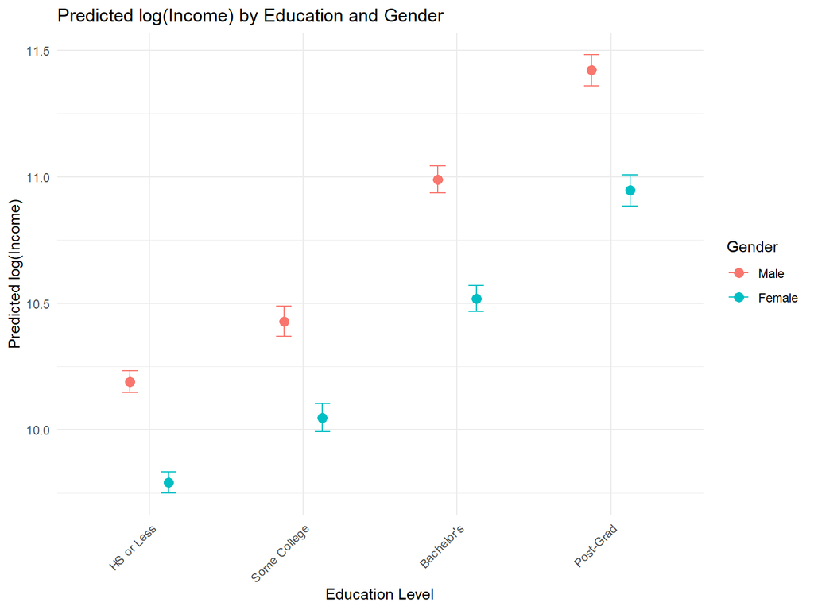

```r
newdata <- expand.grid(
  educ_group = c("HS or Less", "Some College", "Bachelor's", "Post-Grad"),
  gender = unique(df$gender),
  race = unique(df$race),
  age = mean(df$age, na.rm = TRUE),
  state_total_jobs = mean(df$state_total_jobs, na.rm = TRUE),
  state_pc_income = mean(df$state_pc_income, na.rm = TRUE),
  state_real_gdp = mean(df$state_real_gdp, na.rm = TRUE)
)


newdata$educ_group <- factor(newdata$educ_group,levels = c("HS or Less", "Some College", "Bachelor's", "Post-Grad"), ordered = TRUE)
predictions <- predict(model.interaction.state, newdata, se.fit = TRUE, interval = "confidence")
pred_df <- cbind(newdata, predictions)

#colnames(pred_df)
pred_df <- pred_df %>%
  rename(
    log_income_pred = fit.fit,
    ci_lower = fit.lwr,
    ci_upper = fit.upr
  )
pred_summary <- pred_df %>%
  group_by(educ_group, gender) %>%
  summarise(
    log_income_pred = mean(log_income_pred),
    ci_lower = mean(ci_lower),
    ci_upper = mean(ci_upper),
    .groups = "drop"
  )


ggplot(pred_summary, aes(x = educ_group, y = log_income_pred, color = gender)) +
  geom_point(position = position_dodge(width = 0.5), size = 3) +
  geom_errorbar(aes(ymin = ci_lower, ymax = ci_upper),
                width = 0.2,
                position = position_dodge(width = 0.5)) +
  scale_x_discrete(limits = c("HS or Less", "Some College", "Bachelor's", "Post-Grad")) +
  labs(x = "Education Level",
       y = "Predicted log(Income)",
       color = "Gender",
       title = "Predicted log(Income) by Education and Gender") +
  theme_minimal() +
  theme(axis.text.x = element_text(angle = 45, hjust = 1))
```

This interaction plot represents the predicted values of log income for males and females based on their education levels and includes 95% confidence intervals. This graph shows the expected results: as education level increases, income increases. Moreover, males have higher income than females at all education levels.

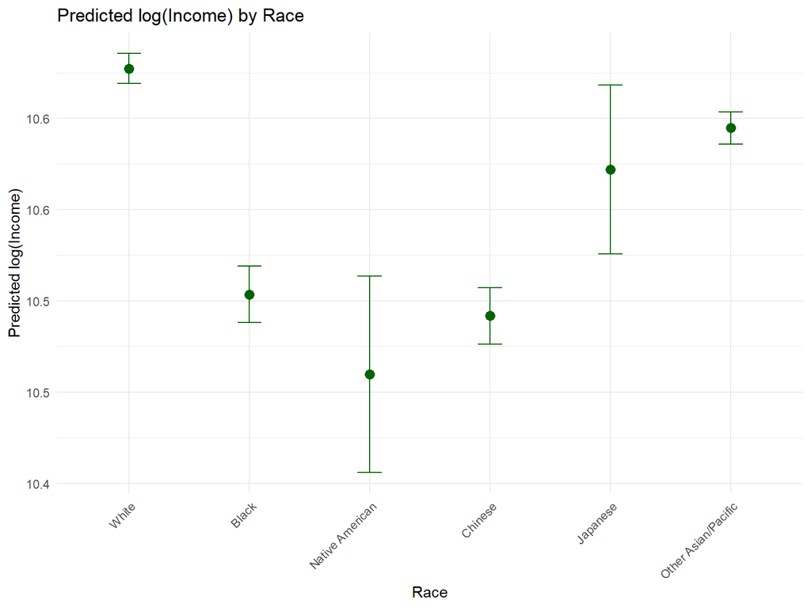

```r
library(emmeans)
race_emm <- emmeans(model.interaction.state, ~ race)
race_df <- as.data.frame(race_emm)
#colnames(race_df)
ggplot(race_df, aes(x = race, y = emmean)) +
  geom_point(size = 3, color = "darkgreen") +
  geom_errorbar(aes(ymin = lower.CL, ymax = upper.CL), width = 0.2, color = "darkgreen") +
  labs(x = "Race",
       y = "Predicted log(Income)",
       title = "Predicted log(Income) by Race") +
  theme_minimal() +
  theme(axis.text.x = element_text(angle = 45, hjust = 1))
```

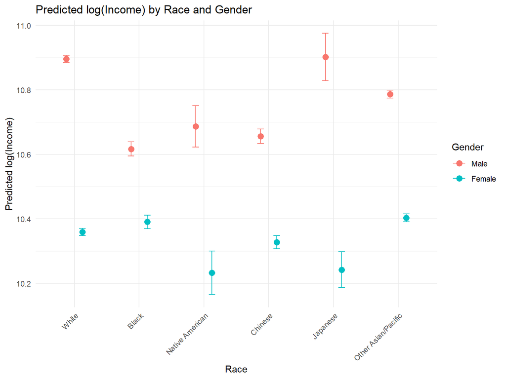

```r
race_gender_emm <- emmeans(model.interaction.state, ~ race * gender)
race_gender_df <- as.data.frame(race_gender_emm)

race_gender_df$race <- factor(race_gender_df$race, levels = levels(df$race))

ggplot(race_gender_df, aes(x = race, y = emmean, color = gender)) +
  geom_point(position = position_dodge(width = 0.5), size = 3) +
  geom_errorbar(aes(ymin = lower.CL, ymax = upper.CL),
                width = 0.2,
                position = position_dodge(width = 0.5)) +
  labs(x = "Race",
       y = "Predicted log(Income)",
       color = "Gender",
       title = "Predicted log(Income) by Race and Gender") +
  theme_minimal() +
  theme(axis.text.x = element_text(angle = 45, hjust = 1))
```

Next, we include a graph of predicted log income based on both race and gender to examine the gender wage gap across different races. Japanese individuals have the largest gender income gap, followed by White individuals, while Black and Chinese individuals have the smallest gender income gap.

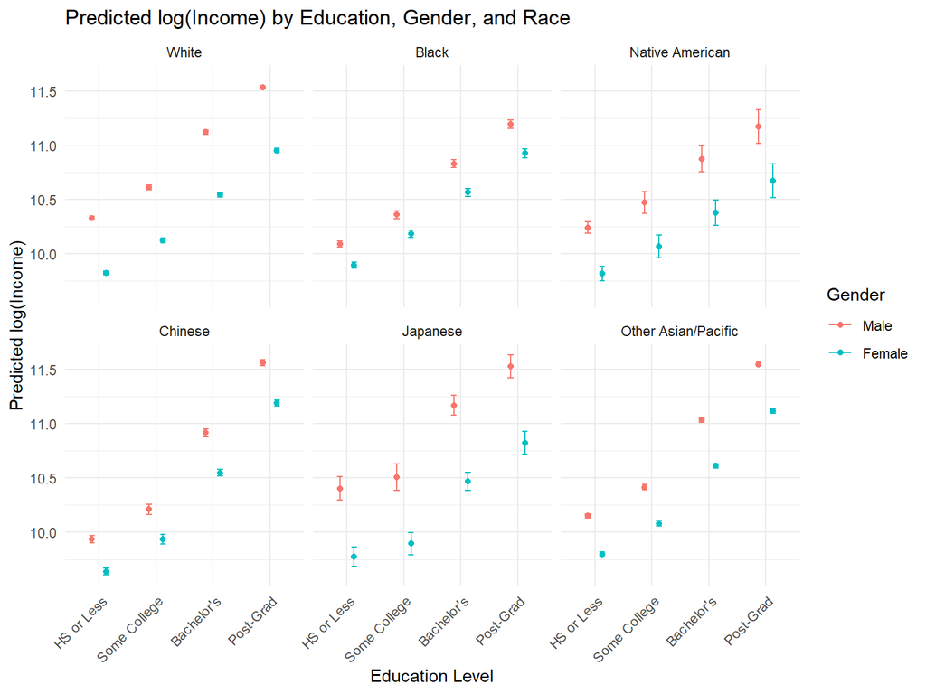

```r
pred_emm <- emmeans(model.interaction.state, ~ educ_group * gender * race)
pred_df <- as.data.frame(pred_emm)


pred_df$educ_group <- factor(pred_df$educ_group,
                             levels = c("HS or Less", "Some College", "Bachelor's", "Post-Grad"),
                             ordered = TRUE)
pred_df$race <- factor(pred_df$race, levels = levels(df$race))
pred_df$gender <- factor(pred_df$gender, levels = levels(df$gender))

ggplot(pred_df, aes(x = educ_group, y = emmean, color = gender)) +
  geom_point(position = position_dodge(width = 0.5), size = 1.5) +
  geom_errorbar(aes(ymin = lower.CL, ymax = upper.CL),
                width = 0.2,
                position = position_dodge(width = 0.5)) +
  facet_wrap(~ race) +
  labs(x = "Education Level",
       y = "Predicted log(Income)",
       color = "Gender",
       title = "Predicted log(Income) by Education, Gender, and Race") +
  theme_minimal() +
  theme(axis.text.x = element_text(angle = 45, hjust = 1))
```

This interaction plot combines all factors, showing predicted log income based on gender, race, and education level. It is clear that log income and education have a positive correlation within every racial group, and the gender income gap persists across all racial groups.

## 5.5 Test the fit of the regression

- Anova Test between models (remove controlling variables)

```r
anova(model.base, model.gender.race)
```

```
## Analysis of Variance Table
##
## Model 1: log(total_income) ~ educ_group
## Model 2: log(total_income) ~ educ_group + gender + race + age
##   Res.Df    RSS Df Sum of Sq    F              Pr(>F)
## 1 229338 333133
## 2 229331 322109  7     11024 1121 <0.0000000000000002 ***
## ---
## Signif. codes:  0 '***' 0.001 '**' 0.01 '*' 0.05 '.' 0.1 ' ' 1
```

An ANOVA test comparing the base model to the model with control variables shows a p-value close to 0, indicating that the control variables—age, gender, and race—significantly improve the model.

```r
anova(model.gender.race, model.interaction)
```

```
## Analysis of Variance Table
##
## Model 1: log(total_income) ~ educ_group + gender + race + age
## Model 2: log(total_income) ~ educ_group * gender + educ_group * race +
##     gender * race + +age
##   Res.Df    RSS Df Sum of Sq    F              Pr(>F)
## 1 229331 322109
## 2 229308 320435 23      1674 52.1 <0.0000000000000002 ***
## ---
## Signif. codes:  0 '***' 0.001 '**' 0.01 '*' 0.05 '.' 0.1 ' ' 1
```

An ANOVA test comparing the model with only control variables to the model with interaction terms shows a p-value close to 0, indicating that adding interaction terms and allowing slopes to vary across race and gender significantly improves the model.

```r
anova(model.interaction, model.interaction.state)
```

```
## Analysis of Variance Table
##
## Model 1: log(total_income) ~ educ_group * gender + educ_group * race +
##     gender * race + +age
## Model 2: log(total_income) ~ educ_group * gender + educ_group * race +
##     gender * race + age + log(state_total_jobs) + log(state_pc_income)
##   Res.Df    RSS Df Sum of Sq   F              Pr(>F)
## 1 229308 320435
## 2 229306 320010  2       425 152 <0.0000000000000002 ***
## ---
## Signif. codes:  0 '***' 0.001 '**' 0.01 '*' 0.05 '.' 0.1 ' ' 1
```

# 6 Tree-based model

## 6.1 Regression tree (restricted version)

### 6.1.1 Grow the tree

**Model Specification**:

To investigate the relationship between educational attainment and income, we employed a regression tree model using the Classification and Regression Trees (CART) algorithm. The model predicts total annual income as a continuous outcome through recursive binary partitioning that minimizes mean squared error at each split.

**Variables and Controls**:

- Predictors included:
  - Demographics: educational level (categorical, as we want to examine each level of education attainment will impact the total income), gender, age, and race
  - State-level macroeconomic controls: log-transformed real GDP, per capita income, and total employment to account for regional economic variations
- Model Parameters
  - Maximum depth: 7 levels to balance complexity with interpretability
  - Complexity parameter (CP): 0.01 (default) for cost-complexity pruning, requiring each split to reduce prediction error by at least 1%

```r
set.seed(1)

df <- df %>%
  mutate(education_cat = factor(education))

income_restricted <- rpart(total_income ~ education_cat + gender + age + race + log(state_real_gdp) + log(state_pc_income) + log(state_total_jobs), data=df, method="anova", control = list(maxdepth = 7) )
```

```r
summary(income_restricted)
```

```
## Call:
## rpart(formula = total_income ~ education_cat + gender + age +
##     race + log(state_real_gdp) + log(state_pc_income) + log(state_total_jobs),
##     data = df, method = "anova", control = list(maxdepth = 7))
##   n= 229342
##
##       CP nsplit rel error xerror    xstd
## 1 0.1085      0     1.000  1.000 0.01010
## 2 0.0302      1     0.892  0.892 0.00927
## 3 0.0172      2     0.861  0.861 0.00909
## 4 0.0100      3     0.844  0.844 0.00891
##
## Variable importance
## education_cat        gender
##            89            11
##
## Node number 1: 229342 observations,    complexity param=0.108
##   mean=7.58e+04, MSE=1.02e+10
##   left son=2 (172509 obs) right son=3 (56833 obs)
##   Primary splits:
##       education_cat        splits as  LLLLLLLLLR, improve=0.10800, (0 missing)
##       gender               splits as  RL,         improve=0.02960, (0 missing)
##       age                  < 64.5 to the right,   improve=0.01970, (0 missing)
##       race                 splits as  RLLRRR,     improve=0.00787, (0 missing)
##       log(state_pc_income) < 11   to the left,    improve=0.00474, (0 missing)
##
## Node number 2: 172509 observations,    complexity param=0.0302
##   mean=5.67e+04, MSE=5.64e+09
##   left son=4 (112056 obs) right son=5 (60453 obs)
##   Primary splits:
##       education_cat        splits as  LLLLLLLLR-, improve=0.07260, (0 missing)
##       gender               splits as  RL,         improve=0.02530, (0 missing)
##       age                  < 24.5 to the left,    improve=0.02050, (0 missing)
##       race                 splits as  RLLRRR,     improve=0.00429, (0 missing)
##       log(state_pc_income) < 11   to the left,    improve=0.00296, (0 missing)
##
## Node number 3: 56833 observations,    complexity param=0.0172
##   mean=1.34e+05, MSE=1.96e+10
##   left son=6 (26178 obs) right son=7 (30655 obs)
##   Primary splits:
```

[output cut: 8 more lines]

```
##       log(state_real_gdp)   < 10.9 to the left,  agree=0.540, adj=0.001, (0 split)
##       log(state_total_jobs) < 13.2 to the left,  agree=0.540, adj=0.001, (0 split)
##       log(state_pc_income)  < 10.8 to the left,  agree=0.539, adj=0.000, (0 split)
##
## Node number 4: 112056 observations
##   mean=4.18e+04, MSE=3.04e+09
##
## Node number 5: 60453 observations
##   mean=8.42e+04, MSE=9.29e+09
##
## Node number 6: 26178 observations
##   mean=1.05e+05, MSE=1.25e+10
##
## Node number 7: 30655 observations
##   mean=1.58e+05, MSE=2.44e+10
```

**Model Summary interpretation**:

1. Complexity Parameter (CP) Table

Cross-validation results show strong performance:

- The model made 3 splits before reaching the CP = 0.01 threshold
- Relative error decreased from 1.000 to 0.844, representing a 15.6% reduction in prediction error
- Cross-validation error (xerror) closely tracks training error, indicating the model generalizes well without overfitting
- Each successive split provides diminishing returns (10.8% → 3.0% → 1.7% → 1.0% reduction)

The tree stopped at 3 splits because the 4th split barely met the 1% improvement threshold, and no subsequent splits would have provided sufficient error reduction to justify additional complexity.

2. Variable Importance Dramatic dominance of education:
- Education: 89% of total variable importance
- Gender: 11% of total variable importance
- All other variables (age, race, state controls): 0% - did not contribute to any splits

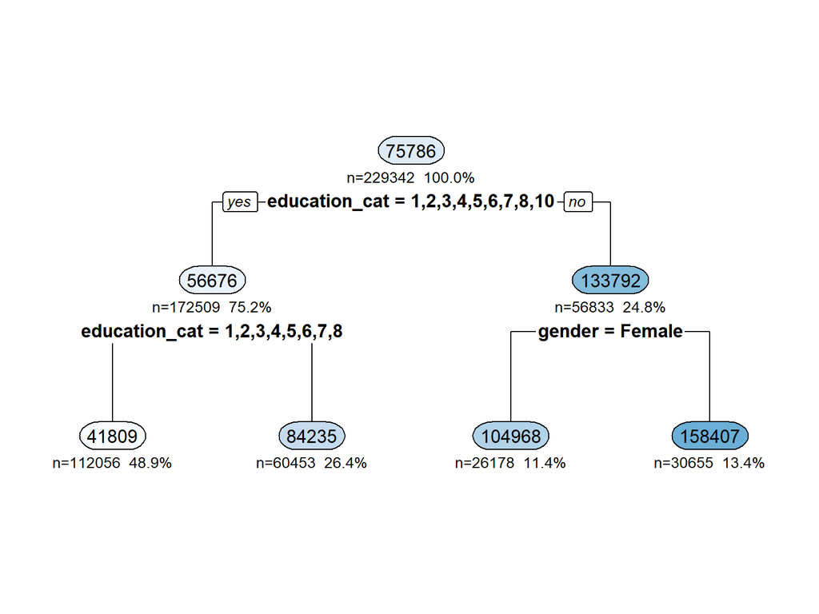

```r
rpart.plot(
  income_restricted,
  type = 2,
  extra = 101,
  under = TRUE,
  faclen = 0,
  digits = -3,
  tweak = 1.1
)
```

**Plot interpretation**

1. Primary Split
- Root node split: Education is the single most important predictor
- Left branch (75.2% of sample, n=172,509): Education levels 1-10 ($\leq$ 4 years of college). Average predicted income: $56,676
- Right branch (24.8% of sample, n=56,833): Education levels 11 (higher educational attainment, 5+ years of college). Average predicted income: $133,792

There’s a dramatic income divide (~$77,000 difference) between those with education levels 1-10 versus 11, representing the clearest earnings premium in the data.

2. Secondary Splits
- Left Branch (Lower Education): Further Split by Education: The lower education group subdivides again by education:
  - Education levels 1-8, meaning $\leq$ 2 years of college (48.9% of total sample): $41,809 average income
  - Higher levels within this group (10 - 4 years of college) (26.4% of total sample): $84,235 average income

This indicates meaningful income gradations even within the lower education categories.

3. Right Branch (Higher Education): Split by Gender

The higher education group subdivides by gender:

- Females (11.4% of total sample): $104,968 average income
- Males (13.4% of total sample): $158,407 average income

Among the highest educated individuals, a substantial gender pay gap exists (~$53,000 difference), suggesting gender disparities are most pronounced at higher education levels.

**Overall Takeaway**

1. Education is the overwhelmingly strongest predictor of income: It defines the first split and most of the structure.
2. Gender is the second-most important variabl: Especially for high education groups.
3. State-level economics barely affect individual income.

### 6.1.2 Prune the Tree

We can “prune” the tree to reduce variance. A plot can be made after pruning, showing the effects in terms of deviance or other statistics.

```r
library(rattle)

print(income_restricted$cptable)
```

```
##       CP nsplit rel error xerror    xstd
## 1 0.1085      0     1.000  1.000 0.01010
## 2 0.0302      1     0.892  0.892 0.00927
## 3 0.0172      2     0.861  0.861 0.00909
## 4 0.0100      3     0.844  0.844 0.00891
```

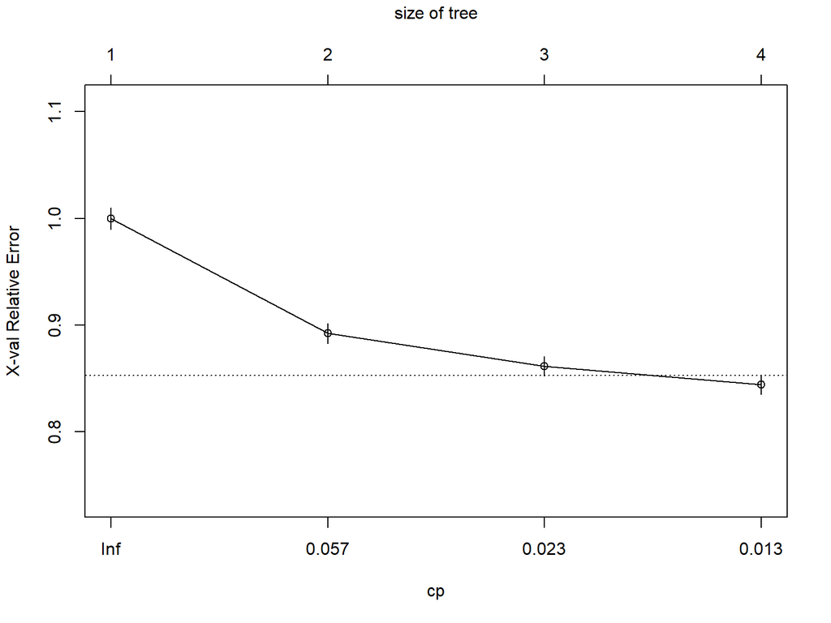

```r
plotcp(income_restricted)
```

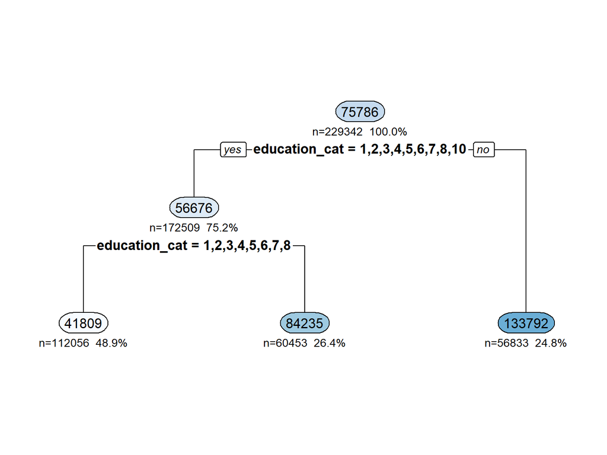

```r
income_prune<- prune(income_restricted, cp = income_restricted$cptable[3,"CP"])
rpart.plot(
  income_prune,
  type = 2,
  extra = 101,
  under = TRUE,
  faclen = 0,
  digits = -3,
  tweak = 1.1
)
```

The pruned tree is simpler than the original:

The tree reveals a simple three-level income hierarchy based purely on education:

- Lowest tier (48.9%): ~$42K - Education levels 1-8
- Middle tier (26.4%): ~$84K - Higher levels education 10
- Highest tier (24.8%): ~$134K - Education levels 11

### 6.1.3 Train/Test Split with Tree Pruning Evaluation

1. First fold Cross-Validation (1-fold CV) for Pruning

```r
set.seed(1)
df$fold <- floor(runif(nrow(df), 1, 5))
test.set <- df[df$fold == 1, ]
train.set <- df[df$fold != 1, ]
```

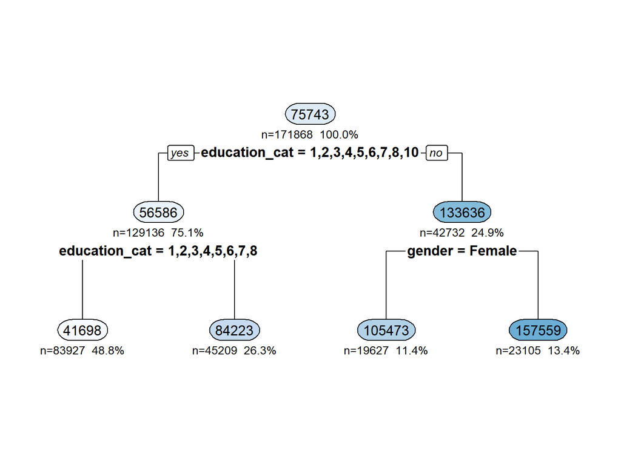

```r
treefit_fold <- rpart(total_income ~ education_cat + gender + age + race +
                        log(state_real_gdp) + log(state_pc_income) + log(state_total_jobs),
                      data = train.set,
                      method = "anova",
                      control = list(maxdepth = 7))
rpart.plot(
  treefit_fold,
  type = 2,
  extra = 101,
  under = TRUE,
  faclen = 0,
  digits = -3,
  tweak = 1.1
)
```

This train set regression tree predicts total income using demographic and economic variables from 171,868 training observations. The tree maintains identical structure: education splits first (categories 1-10), followed by gender within the highest education group. Predicted incomes remain nearly identical to the full tree.

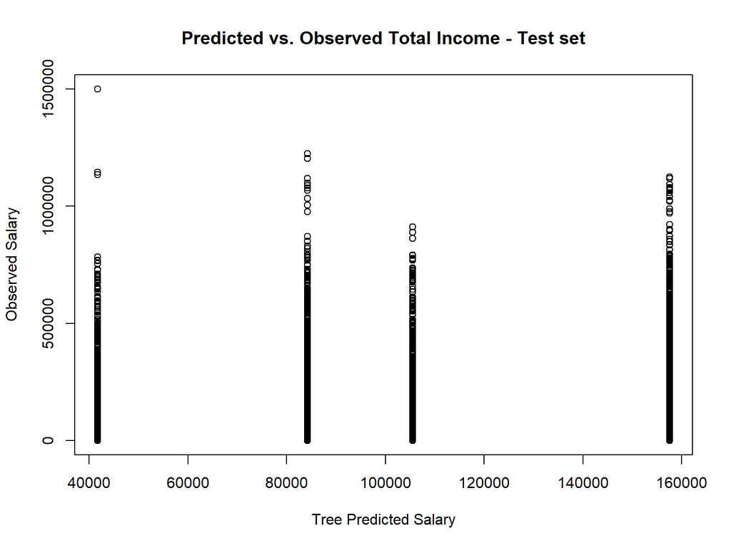

```r
pred <- predict(treefit_fold, test.set)
plot(pred,test.set$total_income, main="Predicted vs. Observed Total Income - Test set", xlab="Tree Predicted Salary", ylab="Observed Salary")
```

```r
treefit_fold_error <- sum((pred - test.set$total_income)^2)
```

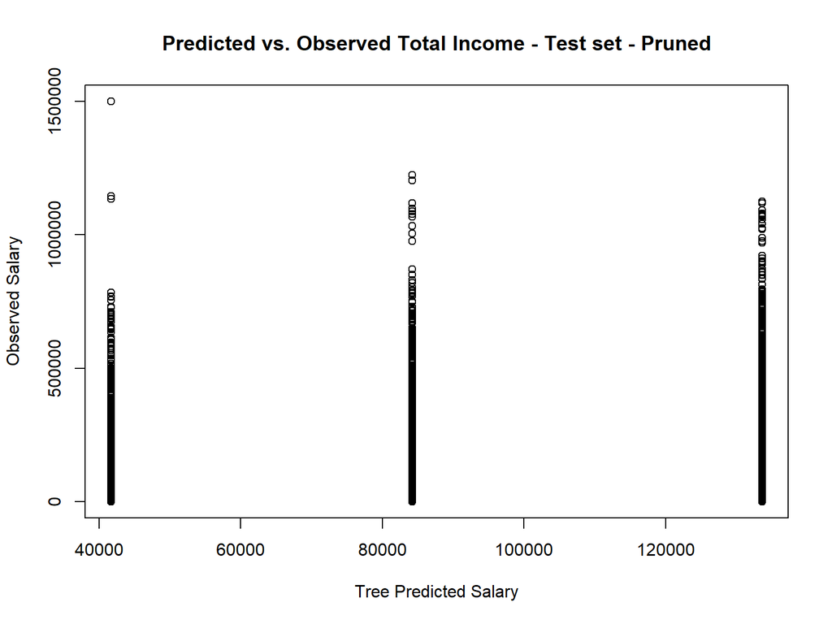

```r
treefit_fold_prune <- prune(treefit_fold,
                            cp = treefit_fold$cptable[3, "CP"])

pred2 <- predict(treefit_fold_prune, test.set)
plot(pred2,test.set$total_income, main="Predicted vs. Observed Total Income - Test set - Pruned", xlab="Tree Predicted Salary", ylab="Observed Salary")
```

```r
treefit_fold_prune_error <- sum((pred2 - test.set$total_income)^2)
```

2. Testing all 5 folds

```r
library(rpart.plot)

set.seed(1)

K <- 5
df$fold_2 <- sample(1:K, size = nrow(df), replace = TRUE)

cv_results <- data.frame(
  fold         = 1:K,
  full_error   = NA_real_,
  pruned_error = NA_real_,
  cp_row3      = NA_real_,
  error_diff   = NA_real_,
  compare      = NA_character_
)

for (k in 1:K) {
  test.set  <- df[df$fold_2 == k, ]
  train.set <- df[df$fold_2 != k, ]

  treefit_k <- rpart(
    total_income ~ education_cat + gender + age + race +
                        log(state_real_gdp) + log(state_pc_income) + log(state_total_jobs),
    data   = train.set,
    method = "anova",
    control = rpart.control(maxdepth = 7)
  )

  pred_full <- predict(treefit_k, newdata = test.set)
  sse_full  <- sum((pred_full - test.set$total_income)^2)
  cv_results$full_error[k] <- sse_full

  cp_row3 <- treefit_k$cptable[3,"CP"]
  cv_results$cp_row3[k] <- cp_row3

  treefit_k_pruned <- prune(treefit_k, cp = cp_row3)

  pred_pruned <- predict(treefit_k_pruned, newdata = test.set)
  sse_pruned  <- sum((pred_pruned - test.set$total_income)^2)
  cv_results$pruned_error[k] <- sse_pruned

  cv_results$error_diff[k] <- sse_pruned - sse_full

  if (sse_pruned < sse_full) {
    cv_results$compare[k] <- "Pruned < Full"
  } else if (sse_pruned > sse_full) {
    cv_results$compare[k] <- "Pruned > Full"
  } else {
    cv_results$compare[k] <- "Pruned = Full"
  }
}


cv_results
```

```
##   fold      full_error    pruned_error cp_row3    error_diff       compare
## 1    1 410566715855956 416855790985636  0.0183 6289075129680 Pruned > Full
## 2    2 396909085540252 404234971720103  0.0176 7325886179850 Pruned > Full
## 3    3 381140047117633 389230656631393  0.0170 8090609513760 Pruned > Full
## 4    4 396598295457063 405575091503745  0.0167 8976796046683 Pruned > Full
## 5    5 393206526645894 402735213822486  0.0164 9528687176592 Pruned > Full
```

Across all five folds of the cross-validation exercise, the pruned tree consistently produced a higher sum of squared errors than the full tree, indicating that pruning reduced predictive accuracy in this dataset. This outcome is expected because the fully grown tree is already extremely small, with only three splits.

By removing an informative split, the pruned tree loses explanatory power and underfits relative to the full model. As a result, the pruned trees capture less variation in total income, leading to systematically worse out-of-sample performance. In this setting, pruning does not improve generalization; the full tree provides the better balance of fit and complexity for predictive accuracy.

Summary table across folds:

```r
error_summary <- data.frame(
  model    = c("Full tree", "Pruned tree"),
  mean_SSE = c(mean(cv_results$full_error),
               mean(cv_results$pruned_error))
)

error_summary
```

```
##         model        mean_SSE
## 1   Full tree 395684134123360
## 2 Pruned tree 403726344932673
```

The summary table of average SSE across folds reinforces the cross-validation results: the full tree achieves a lower mean SSE compared to the pruned tree, indicating that the pruned model performs worse on average. This outcome aligns with the individual-fold results, where pruning consistently increased prediction error.

## 6.2 Tree (unrestricted version)

### 6.2.1 Grow the tree

At the last tree, we set CP to be 0.01, which is the default and restricted value. We now relaxed all the condition to expand the tree

```r
income_full <- rpart(
  total_income ~ education_cat + gender + age + race +
    log(state_real_gdp) + log(state_pc_income) + log(state_total_jobs),
  data   = df,
  method = "anova",
  control = rpart.control(
    maxdepth = 7,
    cp       = 0.001,
    minsplit = 6000,
    minbucket = 2000
  )
)
```

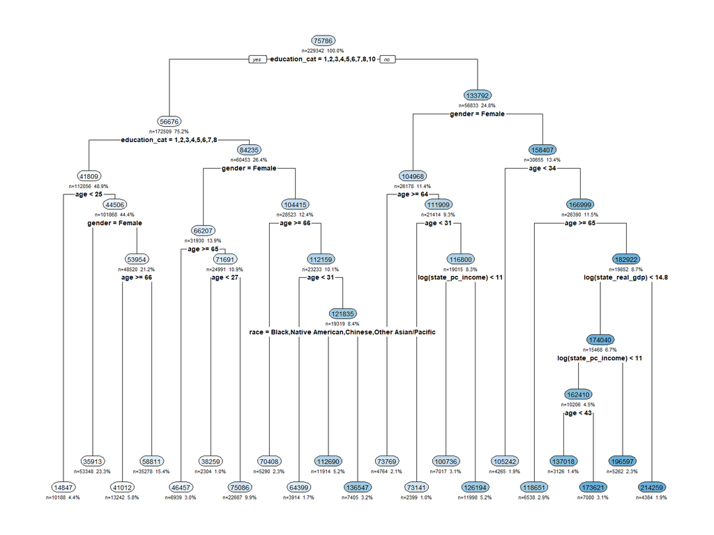

```r
rpart.plot(
  income_full,
  type = 2,
  extra = 101,
  under = TRUE,
  faclen = 0,
  digits = -3,
  tweak = 1.1
)
```

Takeaways from the unrestricted tree:

This means that the unrestricted tree can detect heterogeneity in income patterns that the restricted model is too shallow to capture.

### 6.2.2 Evaluation of restricted and unrestricted tree

```r
set.seed(1)
df$fold_3 <- sample(1:5, size = nrow(df), replace = TRUE)
test.set_unr  <- df[df$fold_3 == 1, ]
train.set_unr <- df[df$fold_3 != 1, ]


income_full_fold <- rpart(
  total_income ~ education_cat + gender + age + race +
    log(state_real_gdp) + log(state_pc_income) + log(state_total_jobs),
  data   = train.set_unr,
  method = "anova",
  control = rpart.control(
    maxdepth  = 7,
    cp        = 0.001,
    minsplit  = 6000,
    minbucket = 2000
  )
)
```

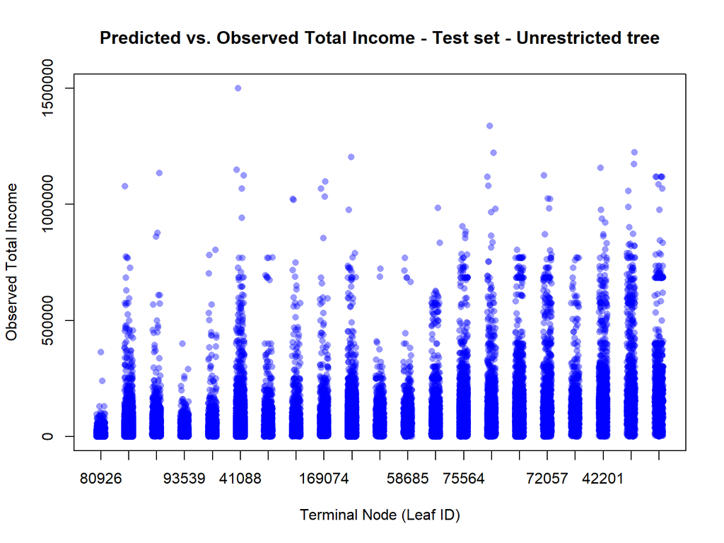

```r
pred_unr <- predict(income_full_fold, newdata = test.set_unr)

leaf_means  <- sort(unique(pred_unr))
leaf_id_num <- match(pred_unr, leaf_means)
leaf_factor <- factor(
  leaf_id_num,
  labels = round(leaf_means, 0)
)

x_numeric <- as.numeric(leaf_factor)

plot(
  jitter(x_numeric, amount = 0.15),
  test.set_unr$total_income,
  xlab = "Terminal Node (Leaf ID)",
  ylab = "Observed Total Income",
  main = "Predicted vs. Observed Total Income - Test set - Unrestricted tree",
  pch = 16,
  col = rgb(0,0,1,0.4),
  xaxt = "n"
)

axis(1, at = unique(x_numeric), labels = levels(leaf_factor))
```

```r
sse_unr_test <- sum((pred_unr - test.set_unr$total_income)^2)
```

```r
SSE_restricted_full <- sum((df$total_income - predict(income_restricted))^2)


SSE_restricted_pruned <- sum((df$total_income - predict(income_prune))^2)

SSE_unrestricted_full <- sum((df$total_income - predict(income_full))^2)

model_compare_full <- data.frame(
  Model = c("Restricted Tree", "Restricted Pruned Tree", "Unrestricted Tree"),
  SSE   = c(SSE_restricted_full, SSE_restricted_pruned, SSE_unrestricted_full)
)

model_compare_full
```

```
##                    Model              SSE
## 1        Restricted Tree 1978254069924518
## 2 Restricted Pruned Tree 2018576957067985
## 3      Unrestricted Tree 1850245217078439
```

# 7 Conclusion

This analysis of 229,342 individuals from the 2023 American Community Survey demonstrates that education is the strongest predictor of income in the United States, with each successive educational level—from high school to some college, bachelor’s degree, and post-graduate education—yielding statistically significant income gains confirmed across ANOVA, regression models, and regression tree analysis.

# 8 Reference

Card, D. (1999). The causal effect of education on earnings. In O. Ashenfelter & D. Card (Eds.), Handbook of labor economics (Vol. 3, pp. 1801–1863). Elsevier. https://doi.org/10.1016/S1573-4463(99)03011-4

Moretti, E. (2004). Human capital externalities in cities. In J. V. Henderson & J.-F. Thisse (Eds.), Handbook of regional and urban economics (Vol. 4, pp. 2243–2291). Elsevier. https://doi.org/10.1016/S1574-0080(04)80014-4

Pan, W. (2025). Firm-specific pay premia and the returns to higher education: Evidence from community colleges. Labour Economics, 93, Article 102685. https://doi.org/10.1016/j.labeco.2025.102685

Ruggles, S., Flood, S., Sobek, M., Backman, D., Cooper, G., Rivera Drew, J. A., Richards, S., Rodgers, R., Schroeder, J., & Williams, K. C. W. (2025). IPUMS USA: Version 16.0 [ACS 1-year microdata for 2023]. IPUMS. https://doi.org/10.18128/D010.V16.0

U.S. Bureau of Economic Analysis. (2023). State Annual Summary Statistics: Personal Income, GDP, Consumer Spending, Price Indexes, and Employment. U.S. Department of Commerce. Retrieved from https://apps.bea.gov/regional/downloadzip.htm